# Spatial patterns of wildfire-induced power outages at different lengths

Shenyue Jia

This notebook produces a bivariate map showing the customers affected of each county and the number of wildfire-induced power outages at different length they may have experienced in 2019.

```r
rm(list = ls())
```

# Prepare data for bivariate mapping

- Read Shapefiles of counties with different lengths of power outages
  - Major: < 1 day
  - Severe: 1-5 days
  - Extreme: 5+ days

```r
major_df <- read_sf(here("result","shapefile-power-outage-diff-length",
                         "ca_county_power_disruption_major.shp"))

severe_df <- read_sf(here("result","shapefile-power-outage-diff-length",
                          "ca_county_power_disruption_severe.shp"))

extreme_df <- read_sf(here("result","shapefile-power-outage-diff-length",
                           "ca_county_power_disruption_extreme.shp"))
```

- Create a data frame with count of severe and extreme events added up

```r
major_df %<>%
  mutate(Count = Count,
         Customers = SumMaxCust,
         DurationType = "< 1 day",
         Label = "Major") %>%
  select(NAME,Count,Customers,DurationType,Label)


severe_df %<>%
  mutate(Count = Count,
         Customers = SumMaxCust,
         DurationType = "1-5 days",
         Label = "Severe")

extreme_df %<>%
  mutate(Count = Count,
         Customers = SumMaxCust,
         DurationType = "5+ days",
         Label = "Extremme")

severe_extreme_df <- inner_join(severe_df %>% as.data.frame(), extreme_df %>% as.data.frame(),
                                by = "GEOID")

severe_extreme_df %<>% st_sf(sf_column_name = 'geometry.x')

severe_extreme_df %<>%
  mutate(NAME = NAME.x,
         Count = Count.x+Count.y,
         Customers = SumMaxCust.x+SumMaxCust.y,
         DurationType = "1 day+",
         Label = "Severe and extreme") %>%
  select(NAME,Count,Customers,DurationType,Label)
```

# Create bivariate plot

- Define a mapping theme

```r
theme_map <- function(...) {
  # theme_ipsum()+
  theme_bw()+
  theme(
    # text = element_text(family = default_font_family,
    #                     color = default_font_color),
    # remove all axes
    axis.line = element_blank(),
    axis.text.x = element_blank(),
    axis.text.y = element_blank(),
    axis.ticks = element_blank(),
    # add a subtle grid
    panel.grid.major = element_blank(),
    panel.grid.minor = element_blank(),
    # background colors
    plot.background = element_rect(
      fill = NULL,
                                   color = NA),
    panel.background = element_rect(
      fill = NULL,
                                    color = NA),
    legend.background = element_rect(
      fill = NULL,
                                     color = NA),
    # borders and margins
    plot.margin = unit(c(2,2,2,2), "mm"),
    panel.border = element_blank(),
    panel.spacing = unit(c(0,0,0,0), "cm"),
    # titles
    legend.title = element_text(size = 11),
    legend.text = element_text(
      # color = default_font_color,
      size = 9, hjust = 0),
    plot.title = element_text(
      # color = default_font_color,
    size = 15, hjust = 0.5),
    plot.subtitle = element_text(size = 10, hjust = 0.5,
                                 # color = default_font_color,
                                 margin = margin(b = -0.1,
                                                 t = -0.1,
                                                 l = 2,
                                                 unit = "cm"),
                                 debug = F),
    # captions
    plot.caption = element_text(size = 7,
                                hjust = .5,
                                margin = margin(t = 0.2,
                                                b = 0,
                                                unit = "cm"),
                                color = "#939184"),
    ...
  )
}
```

- Create a bivariate map color scheme

```r
source(here("code","bivariant_functions.R"))
bivariant_color_scale_major_df <- generate_bivariant_color_df(
                                                   major_df$Customers,
                                                   major_df$Count)
```

- Attach the bivariate color scheme to the major power outage event dataframe (`major_df`)

```r
major_df <- attach_color_df(major_df,
                      bivariant_color_scale_major_df,
                      major_df$Customers,
                      major_df$Count)
# major_df$var1_breaks <- severe_extreme_df$var1_breaks

major_df_bivariant_legend_df <-
  generate_bivarant_legend_df(bivariant_color_scale_major_df,
                                                   major_df$Customers,
                                                   major_df$Count)

# major_df_bivariant_legend_df$var1_label <- severe_extreme_df_bivariant_legend_df$var1_label
```

```r
# source(here("code","bivariant_functions.R"))
bivariant_color_scale_severe_extreme_df <- generate_bivariant_color_df(
                                                   # severe_extreme_df$Customers,
                                                   major_df$Customers,
                                                   severe_extreme_df$Count)
```

```r
severe_extreme_df <- attach_color_df(severe_extreme_df,
                      bivariant_color_scale_severe_extreme_df,
                      # severe_extreme_df$Customers,
                      major_df$Customers,
                      severe_extreme_df$Count)

severe_extreme_df_bivariant_legend_df <- generate_bivarant_legend_df(bivariant_color_scale_severe_extreme_df,
                                                   # severe_extreme_df$Customers,
                                                   major_df$Customers,
                                                   severe_extreme_df$Count)
```

## Plot the bivariate legend

- For severe and extreme events

```r
legend_severe_extreme <- bivariant_legend_plot(severe_extreme_df_bivariant_legend_df)
legend_severe_extreme
```

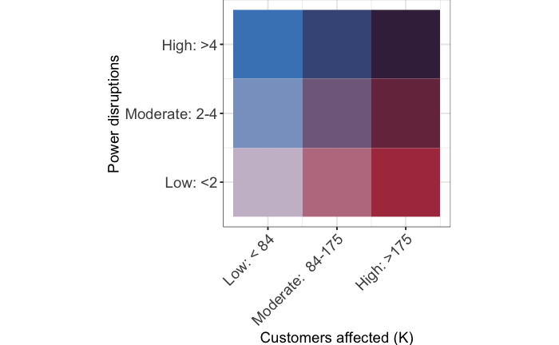

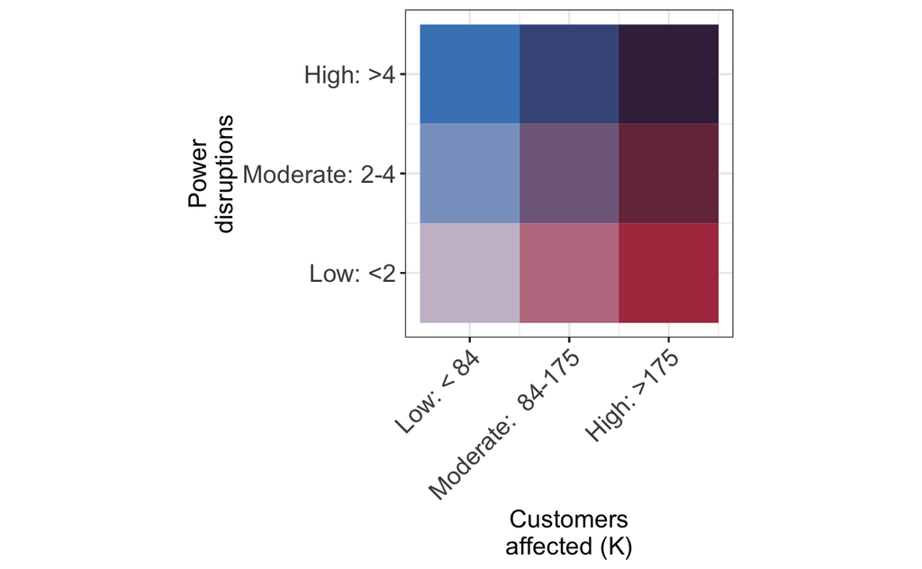

- For major events

```r
legend_major <- bivariant_legend_plot(major_df_bivariant_legend_df)
legend_major
```

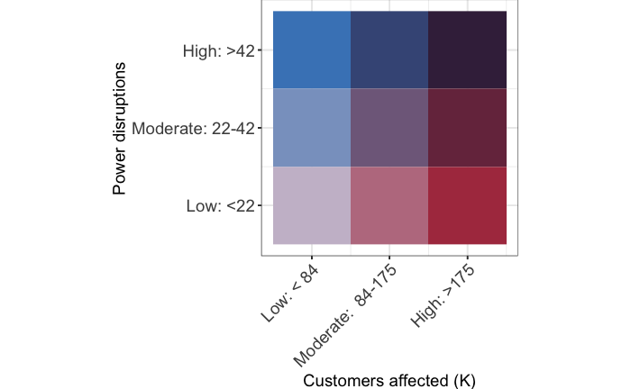

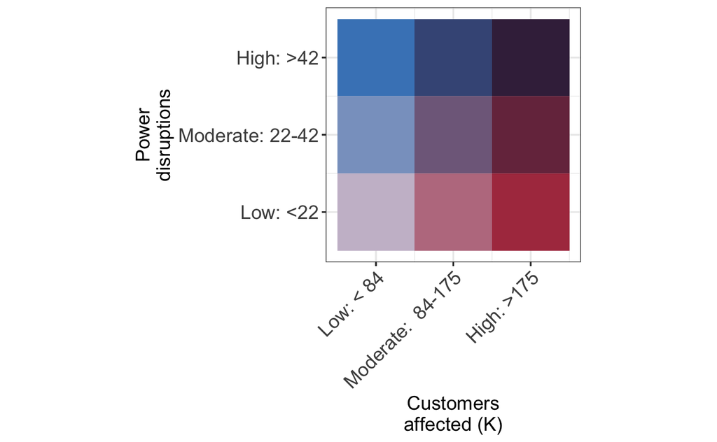